# Lab 1

Author

Olivia Roberts

```r
library(datasauRus)
library(ggplot2)
```

**Question 1**

```r
?datasaurus_dozen
```

```
starting httpd help server ... done
```

```r
table(datasaurus_dozen$dataset)
```

```
      away   bullseye     circle       dino       dots    h_lines high_lines
       142        142        142        142        142        142        142
slant_down   slant_up       star    v_lines wide_lines    x_shape
       142        142        142        142        142        142
```

Answer: The datasaurus_dozen file contains 1846 rows of 3 variables. The 3 variables are a variable called “dataset” that indicates the dataset the data is from, and x-values variable, and a y-values variable. By accessing the dataset column, we can see a list of the 13 datasets inclued in datasaurus_dozen and that they have 142 rows each.

**Question 2**

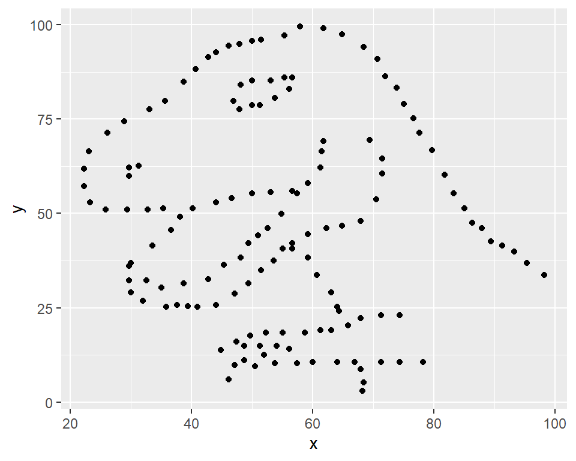

```r
dino_data <- datasaurus_dozen[datasaurus_dozen$dataset == 'dino',]

ggplot(data = dino_data, mapping = aes(x = x, y = y)) +
  geom_point()
```

```r
cor(dino_data$x, dino_data$y)
```

```
[1] -0.06447185
```

**Question 3**

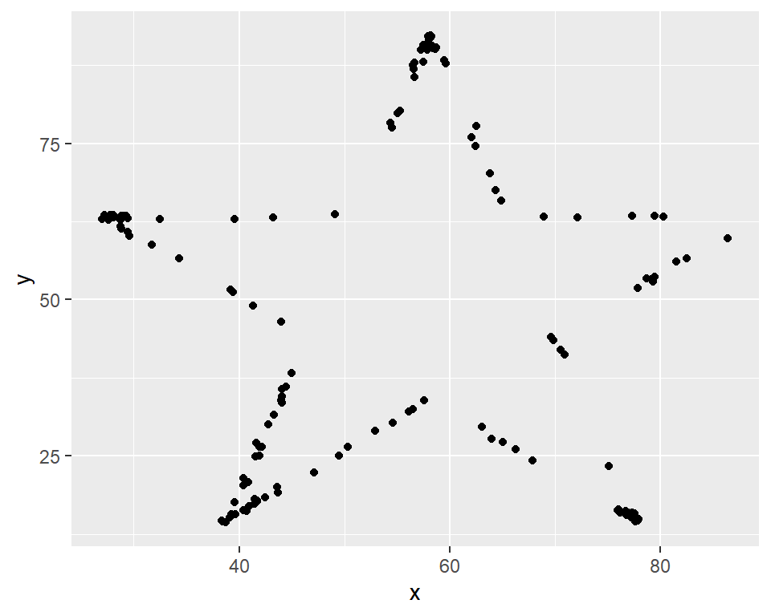

```r
star_data <- datasaurus_dozen[datasaurus_dozen$dataset == 'star',]

ggplot(data = star_data, mapping = aes(x = x, y = y)) +
  geom_point()
```

```r
cor(star_data$x, star_data$y)
```

```
[1] -0.0629611
```

Answer: The correlation coefficient for the dino and star datasets are very similar; they are -0.064 and -0.063 respectively. They are both negative, so in both datasets, as x increases, y decreases. The dino dataset has a slightly stronger negative correlation, but neither of the datasets have a very strong negative correlation since the points are very scattered and the magnitude of the correlation is not very large. Despite having similar correlations, the two datasets look very different.

**Question 4**

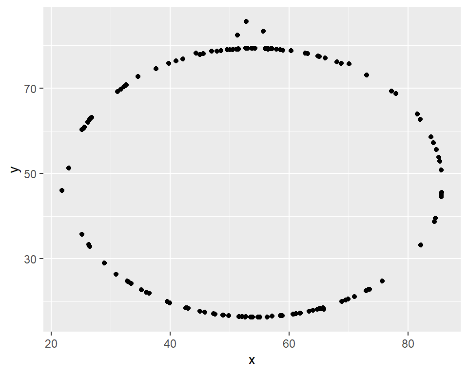

```r
circle_data <- datasaurus_dozen[datasaurus_dozen$dataset == 'circle',]

ggplot(data = circle_data, mapping = aes(x = x, y = y)) +
  geom_point()
```

```r
cor(circle_data$x, circle_data$y)
```

```
[1] -0.06834336
```

Answer: The correlation coefficient of the dino dataset is -0.064, while the correlation coefficient for the circle dataset is -0.068. Again, both datasets have a negative correlation (as x increases, y decreases overall), but the circle dataset now has a slightly stronger magnitude of correlation. However, both datasets still have a very similar magnitude of correlation despite looking very different.

**Question 5**

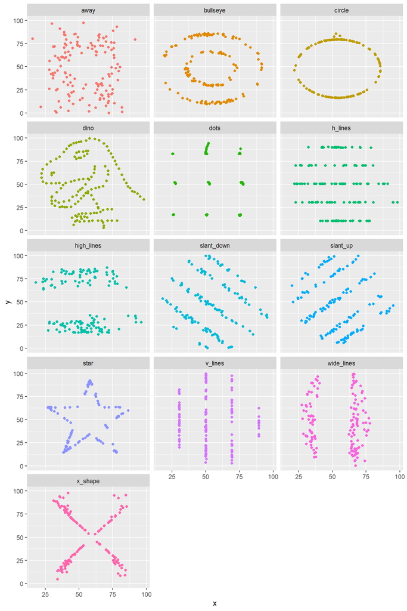

```r
ggplot(datasaurus_dozen, aes(x = x, y = y, color = dataset))+
  geom_point()+
  facet_wrap(~ dataset, ncol = 3) +
  theme(legend.position = "none")
```

**Question 6**

```r
sapply(unique(datasaurus_dozen$dataset), function(name){
    subset <- datasaurus_dozen[datasaurus_dozen$dataset == name, ]
    return(cor(subset$x, subset$y))
})
```

```
       dino        away     h_lines     v_lines     x_shape        star
-0.06447185 -0.06412835 -0.06171484 -0.06944557 -0.06558334 -0.06296110
 high_lines        dots      circle    bullseye    slant_up  slant_down
-0.06850422 -0.06034144 -0.06834336 -0.06858639 -0.06860921 -0.06897974
 wide_lines
-0.06657523
```